# Managing multiple data-frames

## Presented to EdinbR R-Users Group, 2018-07-18

Russ Hyde, University of Glasgow

2018-07-18

## Background and Links:

- @POG_LRC / @GUcancersci / @bloodwise_uk
  - I’m a postdoc bioinformatician at The Paul O’Gorman (POG) Leukaemia Research Centre (University of Glasgow)
  - … working for Prof. Mhairi Copland (POG) and Dr. David Vetrie (Wolfson-Wohl Cancer Research Centre)
  - … on a Bloodwise-funded grant
  - … into chronic-myeloid leukaemia
- @haematobot
  - Personal mumblings about code / analysis / bioinformatics and seemingly very little else …
- https://biolearnr.blogspot.com/
  - Even more mumblings

## Preamble

See `https://github.com/russHyde/polyply`

```r
# Dependencies:
# - purrr, methods, rlang, tidygraph, dplyr
if(! "polyply" %in% installed.packages()){
  require("devtools")
  devtools::install_github(
    repo = "russHyde/polyply", dependencies = FALSE
  )
}

suppressPackageStartupMessages(
  library(polyply)
)
```

## Data-Modelling

## Tidy Data and the Normal-Forms

In tidy data<sup>1</sup>:

- TD1 - Each variable forms a column.
- TD2 - Each observation forms a row.
- TD3 - Each type of observational unit forms a table.
- [TD4 - A key permitting table-joins is present]

See also, Boyce-Codd Normal-Forms<sup>2</sup> and relational-database-design.

- ?? TD5 - A tidy way of encapsulating your nicely decomposed tables
- ?? TD6 - An explicit workflow for combining your tables back together

<sup>1</sup>: http://vita.had.co.nz/papers/tidy-data.html  
<sup>2</sup>: https://en.wikipedia.org/wiki/First_normal_form

## Common *Untidy* Data Structures

Tidy-data / normal-forms in R

- $\downarrow$ duplication
- play nicely with some important things (`ggplot2` etc)

But untidy data-structures are useful if they:

- $\uparrow$ access efficiency
- $\downarrow$ code complexity
- play nicely with other important things

## `Biobase::ExpressionSet`

```r
Biobase::ExpressionSet()
```

[interactive chart not shown]

Figure made with `DiagrammeR`

## `Biobase::ExpressionSet` (cont.)

Conversion of the `assayData` to meet tidy-data standards:

```r
m # our assayData
```

```
##       sample1 sample2 sample3
## gene1    12.2   111.0   129.0
## gene2    19.1    10.5   123.0
## gene3     0.5     3.4     1.1
```

Doesn’t meet tidy-data standards:

- rows correspond to features, columns to samples
- not all variables are in columns (since row-IDs are meaningful)
- entries are the same ‘type’ of variable

Easy fix<sup>3</sup>:

```r
m2 <- reshape2::melt(
    m,
    varnames = c("feature_id", "sample_id"),
    as.is = TRUE
  )

head(m2, 4)
```

|  | feature_id | sample_id | value |
| --- | --- | --- | --- |
| 1 | gene1 | sample1 | 12.2 |
| 2 | gene2 | sample1 | 19.1 |
| 3 | gene3 | sample1 | 0.5 |
| 4 | gene1 | sample2 | 111.0 |

|  | feature_id <chr> | sample_id <chr> | value <dbl> |
| --- | --- | --- | --- |
| 1 | gene1 | sample1 | 12.2 |
| 2 | gene2 | sample1 | 19.1 |
| 3 | gene3 | sample1 | 0.5 |
| 4 | gene1 | sample2 | 111.0 |

4 rows

<sup>3</sup>: ... or as.data.frame / rownames_to_column / gather

## But …

- Matrix representation was more dense
- Lost all encapsulation
- (After modifying featureData / phenoData to match)
  - Have to join rather than index
  - Have to keep track of multiple data-frames, rather than one data-structure

## That multi-data-frame *thing*

For a reasonably complex project:

- tidy-data / normal-forms mean more data-frames

Wanted:

- a lightweight approach to working with multiple ‘conceptually-related’ data-frames
- that plays nicely with `tidyverse` verbs
- that feeds into `ggplot2`
- that plays nicely with untidy data-structures I use *all the time*

## `tidygraph` already (sort of) does this

## Graph theory

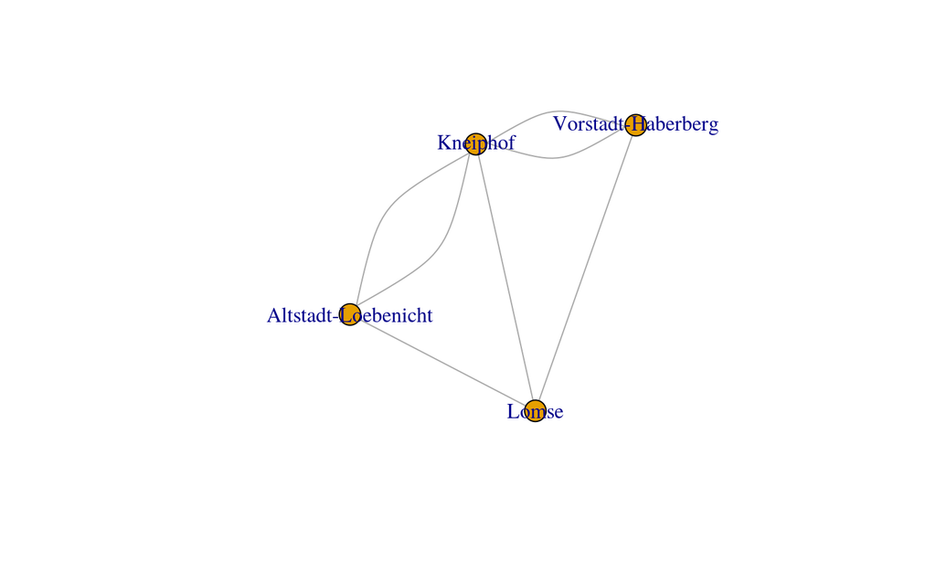

## Basics of ‘graph theory’ speak

A graph is made up of two sets:

- *V*, a set of vertices:
  - aka nodes, actors, …
- *E*, a set of edges:
  - pairwise relationships between vertices
  - aka interactions, lines, arcs, …
- Need to store attributes for both nodes and edges

## `tbl_graph` data structure

`tidygraph` is really a wrapper around the package `igraph`

```r
data("Koenigsberg", package = "igraphdata")
tg <- tidygraph::as_tbl_graph(Koenigsberg)

# Nodes data shows up first:
tg
```

```
## # A tbl_graph: 4 nodes and 7 edges
## #
## # An undirected multigraph with 1 component
## #
## # Node Data: 4 x 2 (active)
##   name                Euler_letter
##   <chr>               <chr>
## 1 Altstadt-Loebenicht B
## 2 Kneiphof            A
## 3 Vorstadt-Haberberg  C
## 4 Lomse               D
## #
## # Edge Data: 7 x 4
##    from    to Euler_letter name
##   <int> <int> <chr>        <chr>
## 1     1     2 a            Kraemer Bruecke
## 2     1     2 b            Schmiedebruecke
## 3     1     4 f            Holzbruecke
## # ... with 4 more rows
```

## `tbl_graph` data structure

```r
# If we make the 'edges' active, the edge-data shows up first:
activate(tg, edges)
```

```
## # A tbl_graph: 4 nodes and 7 edges
## #
## # An undirected multigraph with 1 component
## #
## # Edge Data: 7 x 4 (active)
##    from    to Euler_letter name
##   <int> <int> <chr>        <chr>
## 1     1     2 a            Kraemer Bruecke
## 2     1     2 b            Schmiedebruecke
## 3     1     4 f            Holzbruecke
## 4     2     4 e            Honigbruecke
## 5     3     4 g            Hohe Bruecke
## 6     2     3 c            Gruene Bruecke
## # ... with 1 more row
## #
## # Node Data: 4 x 2
##   name                Euler_letter
##   <chr>               <chr>
## 1 Altstadt-Loebenicht B
## 2 Kneiphof            A
## 3 Vorstadt-Haberberg  C
## # ... with 1 more row
```

## The `activate` verb

Think of the `tbl_graph` as `list[nodes, edges]`

To modify the contents of a given data-frame, `activate` it:

```r
tg %>%
  activate(edges) %>%
  mutate(weight = nchar(name))
```

```
## # A tbl_graph: 4 nodes and 7 edges
## #
## # An undirected multigraph with 1 component
## #
## # Edge Data: 7 x 5 (active)
##    from    to Euler_letter name            weight
##   <int> <int> <chr>        <chr>            <int>
## 1     1     2 a            Kraemer Bruecke     15
## 2     1     2 b            Schmiedebruecke     15
## 3     1     4 f            Holzbruecke         11
## 4     2     4 e            Honigbruecke        12
## 5     3     4 g            Hohe Bruecke        12
## 6     2     3 c            Gruene Bruecke      14
## # ... with 1 more row
## #
## # Node Data: 4 x 2
##   name                Euler_letter
##   <chr>               <chr>
## 1 Altstadt-Loebenicht B
## 2 Kneiphof            A
## 3 Vorstadt-Haberberg  C
## # ... with 1 more row
```

## `polyply` and multiple, linked data-frames

## `polyply`

Aim:

- multiple data-frames in one data-structure
  - $\rightarrow$ class `poly_frame`: extends list`
  - `poly_frame`: [list[data-frame], merge_fn]
- mutation / filtering
- merging

## Exported functions

- `as_poly_frame`
  - convert a data-structure into a `poly_frame`
- `activate`
  - choose a data-frame from within the `poly_frame`
- `filter`
  - modify the contents of the active data-frame
- `merge`
  - user defined data-frame combiner (default: reduce(inner_join)(df_list))
- others to be added (mutate / select etc)

## Examples

## ExpressionSet Example

```r
data("leukemiasEset", package = "leukemiasEset")
leuk <- leukemiasEset
leuk
```

```
## ExpressionSet (storageMode: lockedEnvironment)
## assayData: 20172 features, 60 samples
##   element names: exprs, se.exprs
## protocolData
##   sampleNames: GSM330151.CEL GSM330153.CEL ... GSM331677.CEL (60
##     total)
##   varLabels: ScanDate
##   varMetadata: labelDescription
## phenoData
##   sampleNames: GSM330151.CEL GSM330153.CEL ... GSM331677.CEL (60
##     total)
##   varLabels: Project Tissue ... Subtype (5 total)
##   varMetadata: labelDescription
## featureData: none
## experimentData: use 'experimentData(object)'
## Annotation: genemapperhgu133plus2
```

## Construct a poly-frame from an ExpressionSet

```r
leuk_pf <- list(
  exprs = reshape2::melt(
    exprs(leuk),
    as.is = TRUE,
    varnames = c("feature_id", "sample_id")
  ),
  pheno = tibble::rownames_to_column(
    phenoData(leuk)@data,
    var = "sample_id"
  )
) %>%
  as_poly_frame()
```

## What did we just make?

```r
purrr::map(leuk_pf, head)
```

```
## $exprs
##        feature_id     sample_id    value
## 1 ENSG00000000003 GSM330151.CEL 3.386743
## 2 ENSG00000000005 GSM330151.CEL 3.539030
## 3 ENSG00000000419 GSM330151.CEL 9.822758
## 4 ENSG00000000457 GSM330151.CEL 4.747283
## 5 ENSG00000000460 GSM330151.CEL 3.307188
## 6 ENSG00000000938 GSM330151.CEL 8.230721
##
## $pheno
##       sample_id Project     Tissue LeukemiaType
## 1 GSM330151.CEL   Mile1 BoneMarrow          ALL
## 2 GSM330153.CEL   Mile1 BoneMarrow          ALL
## 3 GSM330154.CEL   Mile1 BoneMarrow          ALL
## 4 GSM330157.CEL   Mile1 BoneMarrow          ALL
## 5 GSM330171.CEL   Mile1 BoneMarrow          ALL
## 6 GSM330174.CEL   Mile1 BoneMarrow          ALL
##           LeukemiaTypeFullName                         Subtype
## 1 Acute Lymphoblastic Leukemia c_ALL/Pre_B_ALL without t(9 22)
## 2 Acute Lymphoblastic Leukemia c_ALL/Pre_B_ALL without t(9 22)
## 3 Acute Lymphoblastic Leukemia c_ALL/Pre_B_ALL without t(9 22)
## 4 Acute Lymphoblastic Leukemia c_ALL/Pre_B_ALL without t(9 22)
## 5 Acute Lymphoblastic Leukemia c_ALL/Pre_B_ALL without t(9 22)
## 6 Acute Lymphoblastic Leukemia c_ALL/Pre_B_ALL without t(9 22)
```

## Filter and plot:

```r
my_plot <- leuk_pf %>%
  # At first, data-frame `exprs` is active
  filter(feature_id %in% c("ENSG00000000003", "ENSG00000000005")) %>%
  # Select a different data-frame for filtering:
  # - you can use non-standard-evaluation in `activate`
  activate(pheno) %>%
  # only look at myeloid leukaemias
  filter(LeukemiaType %in% c("AML", "CML")) %>%
  # default merge: fold an inner-join
  merge() %>%
  ggplot()
```

## Filter and plot(cont.)

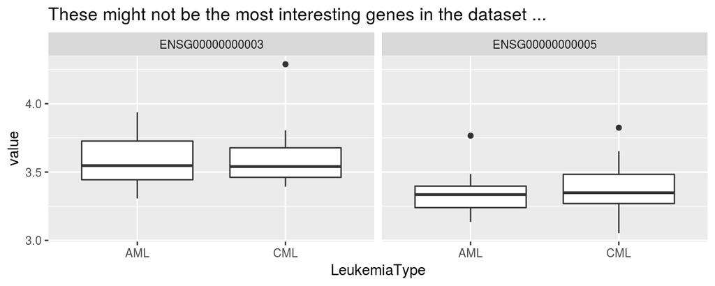

```r
my_plot +
  geom_boxplot(aes(x = LeukemiaType, y = value)) +
  facet_wrap(~ feature_id) +
  ggtitle("These might not be the most interesting genes in the dataset ...")
```

## Taxonomy and brains

```r
data(Animals, package = "MASS")
animals <- Animals %>%
  tibble::rownames_to_column(var = "common_name") %>%
  mutate(
    common_name = str_replace(
      common_name, "Dipliodocus", "Diplodocus"
    )
  )
```

```r
common_to_species <- data.frame(
  common_name = c("Mountain beaver", "Cow", "Grey wolf", "Goat", "Guinea pig",
    "Diplodocus", "Asian elephant", "Donkey", "Horse", "Potar monkey", "Cat"
  ),
  species = c("Aplodontia rufa", "Bos taurus", "Canis lupus",
    "Capra hircus",
    "Cavia porcellus", "Diplodocus longus",
    "Elephas maximus", "Equus africanus asinus",
    "Equus ferus caballus", NA, "Felis silvestris"
  )
)
```

## Taxonomies (cont.)

```r
taxon_data <- taxize::classification(
  x = common_to_species$species,
  get = "order",
  db = "ncbi"
)

taxonomy <- Filter(is.data.frame, taxon_data) %>%
  bind_rows(.id = "species") %>%
  select(-id) %>%
  filter(rank %in% c("order")) %>%
  tidyr::spread(key = rank, value = name)

head(taxonomy)
```

|  | species | order |
| --- | --- | --- |
| 1 | Aplodontia rufa | Rodentia |
| 2 | Canis lupus | Carnivora |
| 3 | Cavia porcellus | Rodentia |
| 4 | Elephas maximus | Proboscidea |
| 5 | Equus africanus asinus | Perissodactyla |
| 6 | Felis silvestris | Carnivora |

|  | species <chr> | order <chr> |
| --- | --- | --- |
| 1 | Aplodontia rufa | Rodentia |
| 2 | Canis lupus | Carnivora |
| 3 | Cavia porcellus | Rodentia |
| 4 | Elephas maximus | Proboscidea |
| 5 | Equus africanus asinus | Perissodactyla |
| 6 | Felis silvestris | Carnivora |

6 rows

## Taxonomies & brains (cont.)

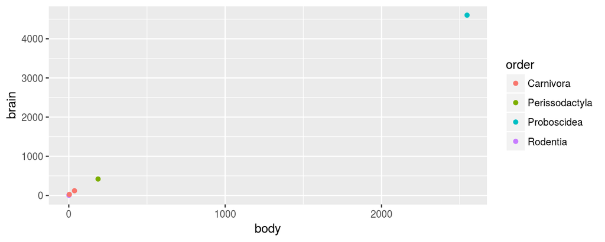

```r
as_poly_frame(
  list(animals, common_to_species, taxonomy)
) %>%
  merge() %>%
  ggplot(aes(x = body, y = brain, col = order)) +
  geom_point() +
  xlim(0, NA) + ylim(0, NA)
```